# BankingChurn.Rmd

2025-12-23

## Refernce used to setup and the XGBoost GPU in windows -> “https://stackoverflow.com/questions/77931563/how-to-use-xgboost-in-r-with-gpu”

```r
knitr::opts_chunk$set(echo = TRUE)

force_reinstall_everything <- FALSE ## <--- change to TRUE to force a reinstall of
                                    ## all packages listed in allowed.packages

## ADD ANY REQUIRED PACKAGES TO THE VECTOR BELOW
## Note: tidyverse includes:  ggplot2, dplyrtidyrreadrpurrrtibble,
##                            stringrforcats, and lubridate.
allowed.packages <- c("tidyverse",
                      "tidymodels",
                      "recipes",
                      "parsnip",
                      "devtools",
                      "bonsai",
                      "healthyR.ai",
                      "knitr",
                      "forcats",
                      "DataExplorer",
                      "visdat",
                      "rsample",
                      "multcomp",
                      "dplyr",
                      "themis",
                      "jsonlite",
                      "data.table"
                      )


## DO NOT CHANGE ANYTHING ELSE IN THIS CODE BLOCK
for (i in seq_along(allowed.packages)){
  if(!(allowed.packages[i] %in% installed.packages()[, 1]) || force_reinstall_everything){
    install.packages(allowed.packages[i],
                     dependencies = c("Depends", "Imports"),
                     repos = "https://cloud.r-project.org")
  }
  library(allowed.packages[i], character.only = TRUE)
}

knitr::opts_chunk$set(echo = TRUE, collapse=TRUE)
ignore <- runif(1) # To initialise the PRNG

cat("\nList of allowed packages (pre-loaded):\n ", paste(allowed.packages, collapse="\n  "))
```

```
##
## List of allowed packages (pre-loaded):
##   tidyverse
##   tidymodels
##   recipes
##   parsnip
##   devtools
##   bonsai
##   healthyR.ai
##   knitr
##   forcats
##   DataExplorer
##   visdat
##   rsample
##   multcomp
##   dplyr
##   themis
##   jsonlite
##   data.table
```

```r
# Load it
library(xgboost)
##
## Attaching package: 'xgboost'
## The following object is masked from 'package:dplyr':
##
##     slice
```

## Load the CSV file from the path “D:/VS_Codes/DataScience/Projects/Banking_Customer_Churn/r_xgb/BankChurners.csv”

```r
# Seed values
seed_value = 123

# File path of the CSV file
file_path = "D:/VS_Codes/DataScience/Projects/Banking_Customer_Churn/r_xgb/BankChurners.csv"

# Load the CSV with read csv method and store it in df
df = read.csv(file = file_path, header = TRUE)

# Print the head to check the CSV loaded or not
head(df)
```

|  | CLIENTNUM | Attrition_Flag | Customer_Age | Gender | Dependent_count | Education_Level | Marital_Status | Income_Category | Card_Category | Months_on_book | Total_Relationship_Count | Months_Inactive_12_mon | Contacts_Count_12_mon | Credit_Limit | Total_Revolving_Bal | Avg_Open_To_Buy | Total_Amt_Chng_Q4_Q1 | Total_Trans_Amt | Total_Trans_Ct | Total_Ct_Chng_Q4_Q1 | Avg_Utilization_Ratio | X |
| --- | --- | --- | --- | --- | --- | --- | --- | --- | --- | --- | --- | --- | --- | --- | --- | --- | --- | --- | --- | --- | --- | --- |
| 1 | 768805383 | Existing Customer | 45 | M | 3 | High School | Married | $60K - $80K | Blue | 39 | 5 | 1 | 3 | 12691 | 777 | 11914 | 1.335 | 1144 | 42 | 1.625 | 0.061 | NA |
| 2 | 818770008 | Existing Customer | 49 | F | 5 | Graduate | Single | Less than $40K | Blue | 44 | 6 | 1 | 2 | 8256 | 864 | 7392 | 1.541 | 1291 | 33 | 3.714 | 0.105 | NA |
| 3 | 713982108 | Existing Customer | 51 | M | 3 | Graduate | Married | $80K - $120K | Blue | 36 | 4 | 1 | 0 | 3418 | 0 | 3418 | 2.594 | 1887 | 20 | 2.333 | 0.000 | NA |
| 4 | 769911858 | Existing Customer | 40 | F | 4 | High School | Unknown | Less than $40K | Blue | 34 | 3 | 4 | 1 | 3313 | 2517 | 796 | 1.405 | 1171 | 20 | 2.333 | 0.760 | NA |
| 5 | 709106358 | Existing Customer | 40 | M | 3 | Uneducated | Married | $60K - $80K | Blue | 21 | 5 | 1 | 0 | 4716 | 0 | 4716 | 2.175 | 816 | 28 | 2.500 | 0.000 | NA |
| 6 | 713061558 | Existing Customer | 44 | M | 2 | Graduate | Married | $40K - $60K | Blue | 36 | 3 | 1 | 2 | 4010 | 1247 | 2763 | 1.376 | 1088 | 24 | 0.846 | 0.311 | NA |

## Basic EDA to check the detailes about the dataset

# Glimpse the dataset # Columns Names # Decide the features and labels # Check the propositions of the feature and plot it

```r
# Glimplse the df
glimpse(df)
## Rows: 10,127
## Columns: 22
## $ CLIENTNUM                <int> 768805383, 818770008, 713982108, 769911858, 7…
## $ Attrition_Flag           <chr> "Existing Customer", "Existing Customer", "Ex…
## $ Customer_Age             <int> 45, 49, 51, 40, 40, 44, 51, 32, 37, 48, 42, 6…
## $ Gender                   <chr> "M", "F", "M", "F", "M", "M", "M", "M", "M", …
## $ Dependent_count          <int> 3, 5, 3, 4, 3, 2, 4, 0, 3, 2, 5, 1, 1, 3, 2, …
## $ Education_Level          <chr> "High School", "Graduate", "Graduate", "High …
## $ Marital_Status           <chr> "Married", "Single", "Married", "Unknown", "M…
## $ Income_Category          <chr> "$60K - $80K", "Less than $40K", "$80K - $120…
## $ Card_Category            <chr> "Blue", "Blue", "Blue", "Blue", "Blue", "Blue…
## $ Months_on_book           <int> 39, 44, 36, 34, 21, 36, 46, 27, 36, 36, 31, 5…
## $ Total_Relationship_Count <int> 5, 6, 4, 3, 5, 3, 6, 2, 5, 6, 5, 6, 3, 5, 5, …
## $ Months_Inactive_12_mon   <int> 1, 1, 1, 4, 1, 1, 1, 2, 2, 3, 3, 2, 6, 1, 2, …
## $ Contacts_Count_12_mon    <int> 3, 2, 0, 1, 0, 2, 3, 2, 0, 3, 2, 3, 0, 3, 2, …
## $ Credit_Limit             <dbl> 12691.0, 8256.0, 3418.0, 3313.0, 4716.0, 4010…
## $ Total_Revolving_Bal      <int> 777, 864, 0, 2517, 0, 1247, 2264, 1396, 2517,…
## $ Avg_Open_To_Buy          <dbl> 11914.0, 7392.0, 3418.0, 796.0, 4716.0, 2763.…
## $ Total_Amt_Chng_Q4_Q1     <dbl> 1.335, 1.541, 2.594, 1.405, 2.175, 1.376, 1.9…
## $ Total_Trans_Amt          <int> 1144, 1291, 1887, 1171, 816, 1088, 1330, 1538…
## $ Total_Trans_Ct           <int> 42, 33, 20, 20, 28, 24, 31, 36, 24, 32, 42, 2…
## $ Total_Ct_Chng_Q4_Q1      <dbl> 1.625, 3.714, 2.333, 2.333, 2.500, 0.846, 0.7…
## $ Avg_Utilization_Ratio    <dbl> 0.061, 0.105, 0.000, 0.760, 0.000, 0.311, 0.0…
## $ X                        <lgl> NA, NA, NA, NA, NA, NA, NA, NA, NA, NA, NA, N…
```

```r
# Get a table of all classes
table(sapply(df, class))
##
## character   integer   logical   numeric
##         6        10         1         5
```

```r
colnames(df)
##  [1] "CLIENTNUM"                "Attrition_Flag"
##  [3] "Customer_Age"             "Gender"
##  [5] "Dependent_count"          "Education_Level"
##  [7] "Marital_Status"           "Income_Category"
##  [9] "Card_Category"            "Months_on_book"
## [11] "Total_Relationship_Count" "Months_Inactive_12_mon"
## [13] "Contacts_Count_12_mon"    "Credit_Limit"
## [15] "Total_Revolving_Bal"      "Avg_Open_To_Buy"
## [17] "Total_Amt_Chng_Q4_Q1"     "Total_Trans_Amt"
## [19] "Total_Trans_Ct"           "Total_Ct_Chng_Q4_Q1"
## [21] "Avg_Utilization_Ratio"    "X"
```

The data frame has 22 columns, the feature columns is the binary values which indicates the churn state of the customer. There are 6 character columns, 15 Numeric columns, and a logical columns.

```r
# Summarize it as a dataframe and plot the bar graph
feature_count.df = as.data.frame(prop.table(table(df$Attrition_Flag)) * 100)
feature_count.df
```

| Var1 | Freq |
| --- | --- |
| Attrited Customer | 16.06596 |
| Existing Customer | 83.93404 |

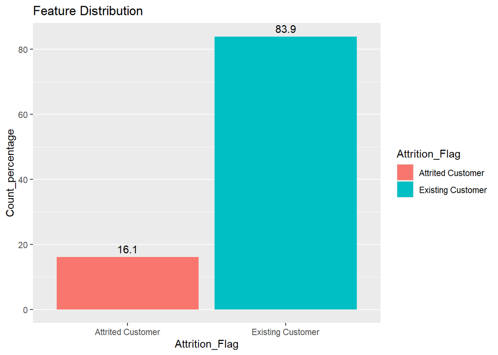

```r
# Set the column names
colnames(feature_count.df) = c("Attrition_Flag", "Count_percentage")

# Plot the percentage of the Attrition Flag
ggplot(feature_count.df, aes(x = Attrition_Flag, y = Count_percentage, fill = Attrition_Flag)) +
  geom_bar(stat = "identity") +
  geom_text(aes(label = round(Count_percentage, 1)),
            vjust = -0.5) +
  labs(title = "Feature Distribution", x = "Attrition_Flag", y = "Count_percentage") +
  theme(panel.grid.major.x = element_blank())
```

## Factor the label column

```r
# Factor the Attrition_Flag
df$Attrition_Flag = as.factor(df$Attrition_Flag)
```

From the columns details, Attrition_Flag is the label to predict about the churn of the bank and rest of the columns are the labels.

## Processing pipeline with the recipe

# Split the data set as train test split for the preprocessing and EDA

```r
# Set the seed
set.seed(seed_value)

# Split the dataset and store it in df.split using initial split method.
df.split = initial_split(df, prop = 0.8)


# Store the train data in df_train and test data in df_test
df_train = training(df.split)
df_test = testing(df.split)


# Check train dataset
colnames(df_train)
##  [1] "CLIENTNUM"                "Attrition_Flag"
##  [3] "Customer_Age"             "Gender"
##  [5] "Dependent_count"          "Education_Level"
##  [7] "Marital_Status"           "Income_Category"
##  [9] "Card_Category"            "Months_on_book"
## [11] "Total_Relationship_Count" "Months_Inactive_12_mon"
## [13] "Contacts_Count_12_mon"    "Credit_Limit"
## [15] "Total_Revolving_Bal"      "Avg_Open_To_Buy"
## [17] "Total_Amt_Chng_Q4_Q1"     "Total_Trans_Amt"
## [19] "Total_Trans_Ct"           "Total_Ct_Chng_Q4_Q1"
## [21] "Avg_Utilization_Ratio"    "X"
```

# Create a recipe with the train data set and store it in the variable

```r
# Create a recipe and store it in a recipe.df with the feature column as Attrition_Flag
recipe.df = recipe(Attrition_Flag ~ ., data = df_train)

recipe.df
##
## ── Recipe ──────────────────────────────────────────────────────────────────────
##
## ── Inputs
## Number of variables by role
## outcome:    1
## predictor: 21
```

## Check the NA values in the entire dataset and plot it with the box plot

# Create a dataframe to calculate the NA values in each column # Plot the bar graphs for the NA data frame

```r
# Calculate the NA values of each column in the df and store it in na.df
na.df = data.frame(
  col = colnames(df),
  na_sum = colSums(is.na(df))
)

na.df
```

|  | col | na_sum |
| --- | --- | --- |
| CLIENTNUM | CLIENTNUM | 0 |
| Attrition_Flag | Attrition_Flag | 0 |
| Customer_Age | Customer_Age | 0 |
| Gender | Gender | 0 |
| Dependent_count | Dependent_count | 0 |
| Education_Level | Education_Level | 0 |
| Marital_Status | Marital_Status | 0 |
| Income_Category | Income_Category | 0 |
| Card_Category | Card_Category | 0 |
| Months_on_book | Months_on_book | 0 |

[output cut: 12 more lines]

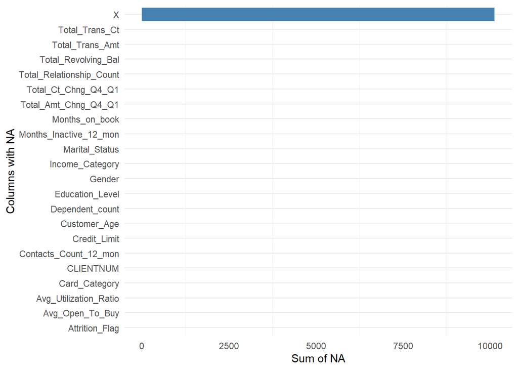

```r
# Bar plot to plot the sum of columns
ggplot(na.df, aes(x = col, y = na_sum)) +
  geom_bar(stat = "identity", fill = "steelblue") +
  theme_minimal() +
  coord_flip() +
  ylab("Sum of NA") +
  xlab("Columns with NA") +
  theme(panel.grid.major.x = element_blank())
```

From the bar graph, there is only one column with more than 10K na values, so remove the columns in the recipe.

## Remove the NA column

```r
# Get the col to remove to store it in the col_remove
col_remove =  na.df %>%
                filter(na_sum > 0) %>%
                pull(col)

col_remove
## [1] "X"


# Update the column to removed na column in recipe as columns_to_remove
recipe.df = recipe.df %>%
              update_role(all_of(col_remove), new_role = "columns_to_remove")

recipe.df
##
## ── Recipe ──────────────────────────────────────────────────────────────────────
##
## ── Inputs
## Number of variables by role
## outcome:            1
## predictor:         20
## columns_to_remove:  1
```

## Check the outliers in the dataset

# Using IQR to find the outliers in each columns and store it in the dataframe # Plot the outliers

```r
# Create a method as count_outlier in each column using the IQR and return the dataframe
count_outlier = function(df) {
  # Get the numeric column and store it in num_cols
  num_cols = sapply(df, is.numeric)

  # Loop each columns in the dataframe using sapply
  # Calculate the outliers of the each columns
  # Store it in the ouliter.df
  outlier.df = data.frame(
    column = names(df)[num_cols],
    n_outliers = sapply(df[, num_cols], function(col) {
      q1  <- quantile(col, 0.25, na.rm = TRUE)
      q3  <- quantile(col, 0.75, na.rm = TRUE)
      iqr <- q3 - q1
      lower <- q1 - 1.5 * iqr
      upper <- q3 + 1.5 * iqr
      sum(col < lower | col > upper)
    })
  )

  # Return the dataframe
  return(outlier.df)
}

# Invoke the method count_outlier to get the outlier and store it in outlier.df
outlier.df = count_outlier(df)

outlier.df
```

|  | column | n_outliers |
| --- | --- | --- |
| CLIENTNUM | CLIENTNUM | 0 |
| Customer_Age | Customer_Age | 2 |
| Dependent_count | Dependent_count | 0 |
| Months_on_book | Months_on_book | 386 |
| Total_Relationship_Count | Total_Relationship_Count | 0 |
| Months_Inactive_12_mon | Months_Inactive_12_mon | 331 |
| Contacts_Count_12_mon | Contacts_Count_12_mon | 629 |
| Credit_Limit | Credit_Limit | 984 |
| Total_Revolving_Bal | Total_Revolving_Bal | 0 |
| Avg_Open_To_Buy | Avg_Open_To_Buy | 963 |

[output cut: 5 more lines]

# Plot the bar graphs

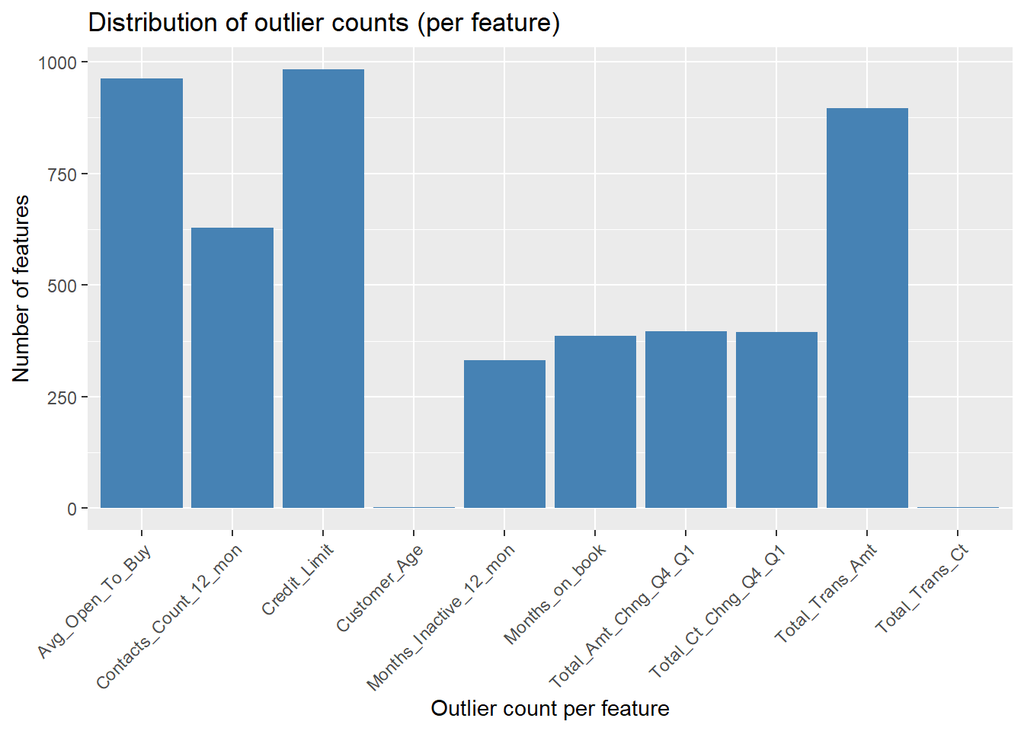

```r
# Plot the point graphs to plot the count of the ouliers in the each columns
ggplot(outlier.df %>% filter(n_outliers > 0), aes(x = column, y = n_outliers)) +
  geom_bar(stat = "identity", fill = "steelblue") +
  labs(title = "Distribution of outlier counts (per feature)",
       x = "Outlier count per feature", y = "Number of features") +
  theme(axis.text.x = element_text(angle=45, hjust = 1))
```

# Separate the columns with the outliers and winsorized it to remove the outliers

```r
# Get the columns with the outliers
outliers_cols = outlier.df %>%
                  filter(n_outliers > 0) %>%
                  pull(column)

outliers_cols
##  [1] "Customer_Age"           "Months_on_book"         "Months_Inactive_12_mon"
##  [4] "Contacts_Count_12_mon"  "Credit_Limit"           "Avg_Open_To_Buy"
##  [7] "Total_Amt_Chng_Q4_Q1"   "Total_Trans_Amt"        "Total_Trans_Ct"
## [10] "Total_Ct_Chng_Q4_Q1"


recipe.df = recipe.df %>%
  # winsorize only the outlier columns
  step_hai_winsorized_truncate(
    outliers_cols,
    fraction = 0.05
  )


recipe.df
##
## ── Recipe ──────────────────────────────────────────────────────────────────────
##
## ── Inputs
## Number of variables by role
## outcome:            1
## predictor:         20
## columns_to_remove:  1
##
## ── Operations
## • Winsorized Truncation Transformation on: outliers_cols
```

# Check the Scale of the numerical columns

# Get the numerical columns # Check the scale using the SD method

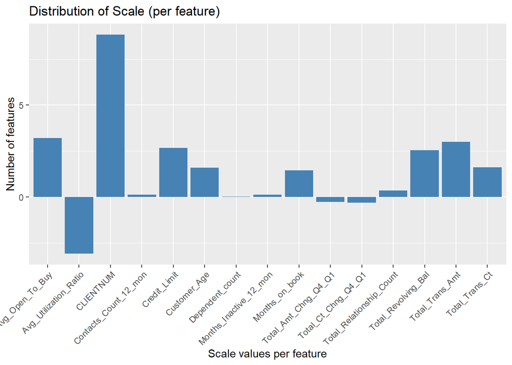

```r
# Get the numerical columns and store it in df_num
df_num = df %>% select_if(is.numeric)

# Create a dataframe with the sd range
df_sd_range = data.frame(
                Features = colnames(df_num),
                SD = sapply(df_num, function(x) sd(x, na.rm = TRUE)),
                Mean = sapply(df_num, function(x) mean(x, na.rm = TRUE))
                ) %>%
                mutate(
                  Range = log10(abs(Mean - SD) + 1e-12),
                  )

# Plot the bar graphs to plot
ggplot(df_sd_range, aes(x = Features, y = Range)) +
  geom_bar(stat = "identity", fill = "steelblue") +
  labs(title = "Distribution of Scale (per feature)",
       x = "Scale values per feature", y = "Number of features") +
  theme(axis.text.x = element_text(angle=45, hjust = 1))
```

# Normalize the values in the recipe.df

```r
# Normalize the numerical predictors using srep normalize
recipe.df = recipe.df %>%
              step_normalize(all_numeric_predictors())

recipe.df
##
## ── Recipe ──────────────────────────────────────────────────────────────────────
##
## ── Inputs
## Number of variables by role
## outcome:            1
## predictor:         20
## columns_to_remove:  1
##
## ── Operations
## • Winsorized Truncation Transformation on: outliers_cols
## • Centering and scaling for: all_numeric_predictors()
```

# Check the Unique values in the each column # Try to minimize the values and combine the values with same semantic meanings. # Encode the values with the recipe

```r
# Create a vectors of the columns names as char_cols
char_cols = c("Card_Category", "Income_Category", "Marital_Status", "Education_Level", "Gender")

# create a function to check the unique values in each of the columns and print the dataframe with the columns names
check_unique = function(df ,vec){

  # Loop the vector
  # Get the unique values and store it in col.unique
  # Create a dataframe with vector and unique values
  return(tibble(
    col = vec,
    unique_values = lapply(df[vec], unique)
  ) %>%
  mutate(unique_values = map_chr(unique_values, ~ paste(.x, collapse = ", "))))
}


print(check_unique(df, char_cols))
## # A tibble: 5 × 2
##   col             unique_values
##   <chr>           <chr>
## 1 Card_Category   Blue, Gold, Silver, Platinum
## 2 Income_Category $60K - $80K, Less than $40K, $80K - $120K, $40K - $60K, $120K…
## 3 Marital_Status  Married, Single, Unknown, Divorced
## 4 Education_Level High School, Graduate, Uneducated, Unknown, College, Post-Gra…
## 5 Gender          M, F
```

# The Card_Category cannot be imputed, since those values are semantically different. The Gender has only M and F are semantically differnt.

# The Income_Category states in different ranges can be converted into Less than 40K, more than 120K, & Average Between 40K to 120K.

# The Marital_Status classify into 4 categories with 3 having the same semantic values, they are merged into 2 categories Married and Single.

# The Education_Level classified into 7 categories with 5 having the same semantic meaning, they are merged into 2 categories as Educated and Uneducated.

```r
recipe.df = recipe.df %>%
              # mark unseen categories when new data arrives
              step_novel(Income_Category) %>%
              # Merge the Income_Category into Less than 40K, more than 120K, & Average Between 40K to 120K
              step_mutate(Income_Category = fct_collapse(
                Income_Category,
                "Less than 40K" = "Less than $40K",
                "More than 120K" = "$120K +",
                "Average Between 40K to 120K" = c(
                  "$40K - $60K",
                  "$60K - $80K",
                  "$80K - $120K",
                  "Unknown"
                )
              )
            ) %>%
            # mark unseen categories when new data arrives
            step_novel(Marital_Status) %>%
            # Merge the Marital_Status into Married and Single
            step_mutate(
              Marital_Status = fct_collapse(
                Marital_Status,
                Married = "Married",
                Single  = intersect(
                  levels(Marital_Status),
                  c("Single", "Unknown", "Divorced")
                )
              )
            ) %>%
            # mark unseen categories when new data arrives
            step_novel(Education_Level) %>%
            # Merge the Education_Level into Educated and Uneducated
            step_mutate(
              Education_Level = fct_collapse(
                Education_Level,
                  Uneducated = c(
                    "Uneducated",
                    "Unknown"
                    ),
                  Educated = c(
                    "High School",
                    "Graduate",
                    "College",
                    "Post-Graduate",
                    "Doctorate"
                  )
                )
              )

recipe.df
##
## ── Recipe ──────────────────────────────────────────────────────────────────────
##
## ── Inputs
## Number of variables by role
## outcome:            1
## predictor:         20
## columns_to_remove:  1
##
## ── Operations
## • Winsorized Truncation Transformation on: outliers_cols
## • Centering and scaling for: all_numeric_predictors()
## • Novel factor level assignment for: Income_Category
## • Variable mutation for: fct_collapse(Income_Category, `Less than 40K` = "Less
##   than $40K", `More than 120K` = "$120K +", `Average Between 40K to 120K` =
##   c("$40K - $60K", "$60K - $80K", "$80K - $120K", "Unknown"))
## • Novel factor level assignment for: Marital_Status
## • Variable mutation for: fct_collapse(Marital_Status, Married = "Married",
##   Single = intersect(levels(Marital_Status), c("Single", "Unknown",
##   "Divorced")))
## • Novel factor level assignment for: Education_Level
## • Variable mutation for: fct_collapse(Education_Level, Uneducated =
##   c("Uneducated", "Unknown"), Educated = c("High School", "Graduate",
##   "College", "Post-Graduate", "Doctorate"))
```

# Encode all the above categorial variables with one-hot encoding.

```r
# Categorical values
char_cols
## [1] "Card_Category"   "Income_Category" "Marital_Status"  "Education_Level"
## [5] "Gender"

recipe.df = recipe.df %>%
              # One-hot encode using dummy method for all the character columns
              step_dummy(
                char_cols,
                one_hot = TRUE
              )

recipe.df
##
## ── Recipe ──────────────────────────────────────────────────────────────────────
##
## ── Inputs
## Number of variables by role
## outcome:            1
## predictor:         20
## columns_to_remove:  1
##
## ── Operations
## • Winsorized Truncation Transformation on: outliers_cols
## • Centering and scaling for: all_numeric_predictors()
## • Novel factor level assignment for: Income_Category
## • Variable mutation for: fct_collapse(Income_Category, `Less than 40K` = "Less
##   than $40K", `More than 120K` = "$120K +", `Average Between 40K to 120K` =
##   c("$40K - $60K", "$60K - $80K", "$80K - $120K", "Unknown"))
## • Novel factor level assignment for: Marital_Status
## • Variable mutation for: fct_collapse(Marital_Status, Married = "Married",
##   Single = intersect(levels(Marital_Status), c("Single", "Unknown",
##   "Divorced")))
## • Novel factor level assignment for: Education_Level
## • Variable mutation for: fct_collapse(Education_Level, Uneducated =
##   c("Uneducated", "Unknown"), Educated = c("High School", "Graduate",
##   "College", "Post-Graduate", "Doctorate"))
## • Dummy variables from: char_cols
```

## Find the correlation and causion between the variables to check the variables relations.

```
# Plot the correlations and plot it.
```

```r
# Find all the numerical columns
df_num
```

| CLIENTNUM | Customer_Age | Dependent_count | Months_on_book | Total_Relationship_Count | Months_Inactive_12_mon | Contacts_Count_12_mon | Credit_Limit | Total_Revolving_Bal | Avg_Open_To_Buy | Total_Amt_Chng_Q4_Q1 | Total_Trans_Amt | Total_Trans_Ct | Total_Ct_Chng_Q4_Q1 | Avg_Utilization_Ratio |
| --- | --- | --- | --- | --- | --- | --- | --- | --- | --- | --- | --- | --- | --- | --- |
| 768805383 | 45 | 3 | 39 | 5 | 1 | 3 | 12691.0 | 777 | 11914.0 | 1.335 | 1144 | 42 | 1.625 | 0.061 |
| 818770008 | 49 | 5 | 44 | 6 | 1 | 2 | 8256.0 | 864 | 7392.0 | 1.541 | 1291 | 33 | 3.714 | 0.105 |
| 713982108 | 51 | 3 | 36 | 4 | 1 | 0 | 3418.0 | 0 | 3418.0 | 2.594 | 1887 | 20 | 2.333 | 0.000 |
| 769911858 | 40 | 4 | 34 | 3 | 4 | 1 | 3313.0 | 2517 | 796.0 | 1.405 | 1171 | 20 | 2.333 | 0.760 |
| 709106358 | 40 | 3 | 21 | 5 | 1 | 0 | 4716.0 | 0 | 4716.0 | 2.175 | 816 | 28 | 2.500 | 0.000 |
| 713061558 | 44 | 2 | 36 | 3 | 1 | 2 | 4010.0 | 1247 | 2763.0 | 1.376 | 1088 | 24 | 0.846 | 0.311 |
| 810347208 | 51 | 4 | 46 | 6 | 1 | 3 | 34516.0 | 2264 | 32252.0 | 1.975 | 1330 | 31 | 0.722 | 0.066 |
| 818906208 | 32 | 0 | 27 | 2 | 2 | 2 | 29081.0 | 1396 | 27685.0 | 2.204 | 1538 | 36 | 0.714 | 0.048 |
| 710930508 | 37 | 3 | 36 | 5 | 2 | 0 | 22352.0 | 2517 | 19835.0 | 3.355 | 1350 | 24 | 1.182 | 0.113 |
| 719661558 | 48 | 2 | 36 | 6 | 3 | 3 | 11656.0 | 1677 | 9979.0 | 1.524 | 1441 | 32 | 0.882 | 0.144 |

[output cut: 9990 more lines]

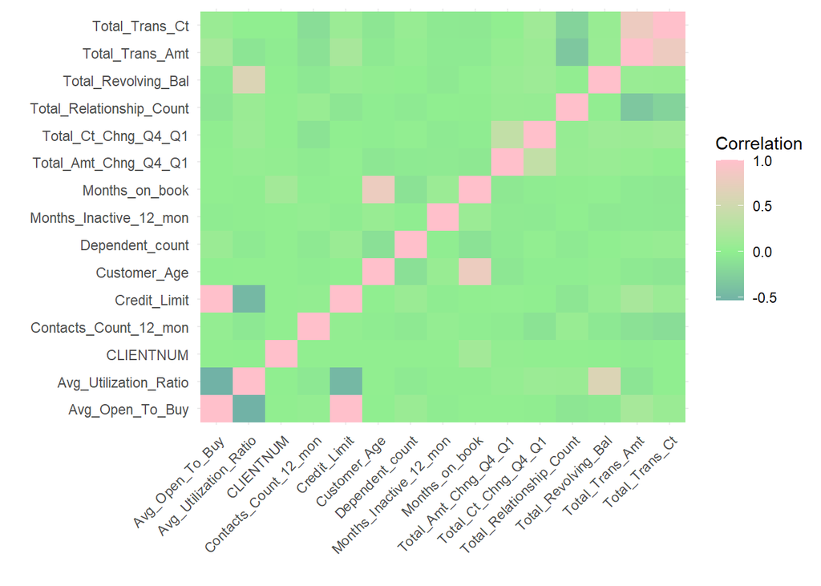

```r
# Find the correlation and store it in cor.mat
cor.mat = cor(df_num, use = "pairwise.complete.obs")

cor.mat
##                              CLIENTNUM Customer_Age Dependent_count
## CLIENTNUM                 1.0000000000  0.007612651     0.006771737
## Customer_Age              0.0076126512  1.000000000    -0.122253752
## Dependent_count           0.0067717372 -0.122253752     1.000000000
## Months_on_book            0.1345878309  0.788912359    -0.103062281
## Total_Relationship_Count  0.0069069051 -0.010931069    -0.039076389
## Months_Inactive_12_mon    0.0057285276  0.054360999    -0.010767918
## Contacts_Count_12_mon     0.0056944278 -0.018451855    -0.040504960
## Credit_Limit              0.0057076227  0.002476227     0.068064600
## Total_Revolving_Bal       0.0008245041  0.014779895    -0.002688146
## Avg_Open_To_Buy           0.0056325068  0.001150678     0.068291304
## Total_Amt_Chng_Q4_Q1      0.0173693399 -0.062042092    -0.035439429
## Total_Trans_Amt          -0.0196917088 -0.046446491     0.025046238
## Total_Trans_Ct           -0.0029610131 -0.067096864     0.049912477
## Total_Ct_Chng_Q4_Q1       0.0076955755 -0.012142548     0.011087181
## Avg_Utilization_Ratio     0.0002659600  0.007114222    -0.037135159
##                          Months_on_book Total_Relationship_Count
## CLIENTNUM                   0.134587831              0.006906905
## Customer_Age                0.788912359             -0.010931069
## Dependent_count            -0.103062281             -0.039076389
## Months_on_book              1.000000000             -0.009203080
## Total_Relationship_Count   -0.009203080              1.000000000
## Months_Inactive_12_mon      0.074163514             -0.003675377
## Contacts_Count_12_mon      -0.010774479              0.055203163
## Credit_Limit                0.007507009             -0.071385817
## Total_Revolving_Bal         0.008622804              0.013725849
## Avg_Open_To_Buy             0.006732392             -0.072601363
## Total_Amt_Chng_Q4_Q1       -0.048959320              0.050118644
## Total_Trans_Amt            -0.038590629             -0.347228880
## Total_Trans_Ct             -0.049819084             -0.241890850
## Total_Ct_Chng_Q4_Q1        -0.014071671              0.040831148
## Avg_Utilization_Ratio      -0.007540837              0.067662878
##                          Months_Inactive_12_mon Contacts_Count_12_mon
## CLIENTNUM                           0.005728528           0.005694428
## Customer_Age                        0.054360999          -0.018451855
## Dependent_count                    -0.010767918          -0.040504960
## Months_on_book                      0.074163514          -0.010774479
## Total_Relationship_Count           -0.003675377           0.055203163
## Months_Inactive_12_mon              1.000000000           0.029492910
## Contacts_Count_12_mon               0.029492910           1.000000000
## Credit_Limit                       -0.020393791           0.020817012
## Total_Revolving_Bal                -0.042209609          -0.053912731
## Avg_Open_To_Buy                    -0.016605384           0.025645961
## Total_Amt_Chng_Q4_Q1               -0.032246712          -0.024445115
## Total_Trans_Amt                    -0.036982425          -0.112773929
## Total_Trans_Ct                     -0.042787039          -0.152212605
## Total_Ct_Chng_Q4_Q1                -0.038989338          -0.094996916
## Avg_Utilization_Ratio              -0.007502633          -0.055471285
##                          Credit_Limit Total_Revolving_Bal Avg_Open_To_Buy
## CLIENTNUM                 0.005707623        0.0008245041     0.005632507
## Customer_Age              0.002476227        0.0147798946     0.001150678
## Dependent_count           0.068064600       -0.0026881459     0.068291304
## Months_on_book            0.007507009        0.0086228045     0.006732392
## Total_Relationship_Count -0.071385817        0.0137258489    -0.072601363
## Months_Inactive_12_mon   -0.020393791       -0.0422096088    -0.016605384
## Contacts_Count_12_mon     0.020817012       -0.0539127312     0.025645961
## Credit_Limit              1.000000000        0.0424926073     0.995980544
## Total_Revolving_Bal       0.042492607        1.0000000000    -0.047167128
## Avg_Open_To_Buy           0.995980544       -0.0471671279     1.000000000
## Total_Amt_Chng_Q4_Q1      0.012812536        0.0581736645     0.007594529
## Total_Trans_Amt           0.171730150        0.0643704770     0.165923228
## Total_Trans_Ct            0.075926912        0.0560604930     0.070885102
## Total_Ct_Chng_Q4_Q1      -0.002019850        0.0898610078    -0.010075538
## Avg_Utilization_Ratio    -0.482965071        0.6240219910    -0.538807748
##                          Total_Amt_Chng_Q4_Q1 Total_Trans_Amt Total_Trans_Ct
## CLIENTNUM                         0.017369340     -0.01969171   -0.002961013
## Customer_Age                     -0.062042092     -0.04644649   -0.067096864
## Dependent_count                  -0.035439429      0.02504624    0.049912477
## Months_on_book                   -0.048959320     -0.03859063   -0.049819084
## Total_Relationship_Count          0.050118644     -0.34722888   -0.241890850
## Months_Inactive_12_mon           -0.032246712     -0.03698243   -0.042787039
## Contacts_Count_12_mon            -0.024445115     -0.11277393   -0.152212605
## Credit_Limit                      0.012812536      0.17173015    0.075926912
## Total_Revolving_Bal               0.058173664      0.06437048    0.056060493
## Avg_Open_To_Buy                   0.007594529      0.16592323    0.070885102
## Total_Amt_Chng_Q4_Q1              1.000000000      0.03967759    0.005468567
## Total_Trans_Amt                   0.039677592      1.00000000    0.807192035
## Total_Trans_Ct                    0.005468567      0.80719203    1.000000000
## Total_Ct_Chng_Q4_Q1               0.384189256      0.08558098    0.112324440
## Avg_Utilization_Ratio             0.035234835     -0.08303425    0.002838112
##                          Total_Ct_Chng_Q4_Q1 Avg_Utilization_Ratio
## CLIENTNUM                        0.007695575           0.000265960
## Customer_Age                    -0.012142548           0.007114222
## Dependent_count                  0.011087181          -0.037135159
## Months_on_book                  -0.014071671          -0.007540837
## Total_Relationship_Count         0.040831148           0.067662878
## Months_Inactive_12_mon          -0.038989338          -0.007502633
## Contacts_Count_12_mon           -0.094996916          -0.055471285
## Credit_Limit                    -0.002019850          -0.482965071
## Total_Revolving_Bal              0.089861008           0.624021991
## Avg_Open_To_Buy                 -0.010075538          -0.538807748
## Total_Amt_Chng_Q4_Q1             0.384189256           0.035234835
## Total_Trans_Amt                  0.085580976          -0.083034246
## Total_Trans_Ct                   0.112324440           0.002838112
## Total_Ct_Chng_Q4_Q1              1.000000000           0.074143210
## Avg_Utilization_Ratio            0.074143210           1.000000000

# convert to tidy format using pivot_longer
corr_long = cor.mat %>%
  as.data.frame() %>%
  mutate(var1 = rownames(.)) %>%
  pivot_longer(
    cols = -var1,
    names_to = "var2",
    values_to = "correlation"
  )

# Plot the correlation between the variables as heat map
ggplot(corr_long, aes(var1, var2, fill = correlation)) +
  geom_tile() +
  scale_fill_gradient2(
    low = "steelblue",
    high = "pink",
    mid = "#90EE90",
    midpoint = 0
  ) +
  theme_minimal() +
  theme(axis.text.x = element_text(angle = 45, hjust = 1)) +
  labs(x = "", y = "", fill = "Correlation")
```